# Visualization Assignment: Crime Analytics

January 21, 2016

**Description**

An assignment is a part of ‘’Data Sience at Scale’’ course on Coursera. In the given assignment, students are asked to analyze criminal incident data from Seattle or San Francisco to visualize patterns and, if desired, contrast and compare patterns across the two cities. One should produce a blog-post-style visual narrative consisting of a series of visualizations interspersed with sufficient descriptive text to make a convincing argument.

**Data**

The data set used in this report is about Police Incident Reports of the city of San Francisco, on the Summer 2014. The data set is provided by Coursera.

**Programming and Software**

The code is written with R v.3.2.1 using RStudio v.0.99.484

**Libraries**

**Read The Data**

```r
SF <-  read.csv("data/sanfrancisco_incidents_summer_2014.csv", stringsAsFactors = FALSE)
```

**Exploratory Analysis**

In general, the data can be understood in terms of a variable Category that has 34 levels. With the following analysis, one can find that the top category of incidents is Larceny/theft with 9,466, followed by Other Offenses (3,567) and Non-criminal (3,023).

```r
Data <- as.data.frame(table(SF$Category), stringsAsFactors = FALSE)
colnames(Data) <- c("Category", "Frequency")
Data <- Data[order(Data$Frequency, decreasing = TRUE), ]
Data$Category  <- factor(Data$Category, levels = Data$Category)
Data <- Data[1:15, ]
```

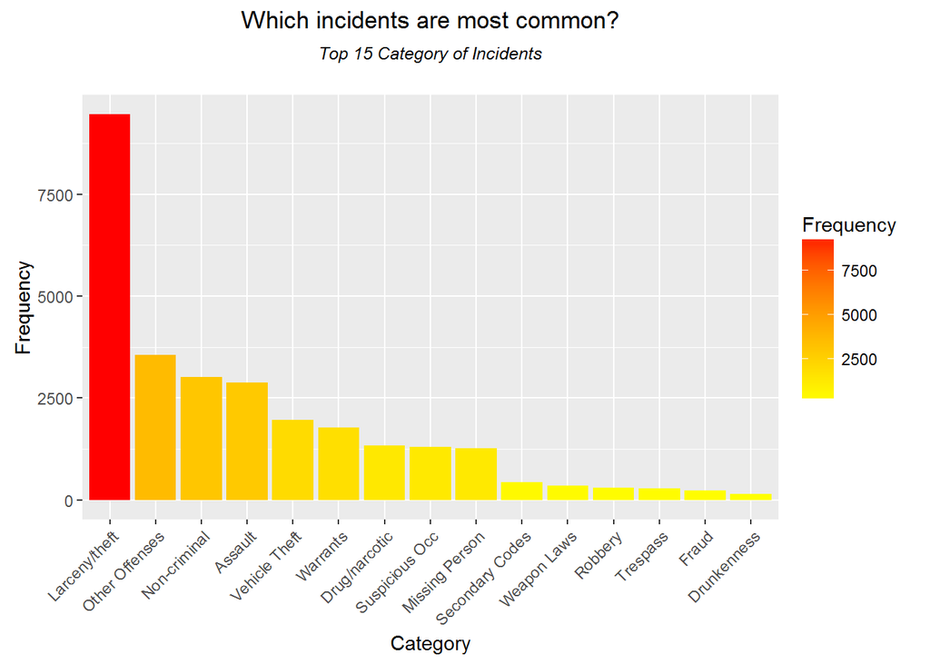

Next, one can find that during the week the incidents occur more in the evenings starting from 17 to 18 hours, stretching to 20 hours. There is also a second concentration around 12 hours. During weekends and including Fridays, the incidents are concentrated in the evening and then at late hours, around 23 hours.

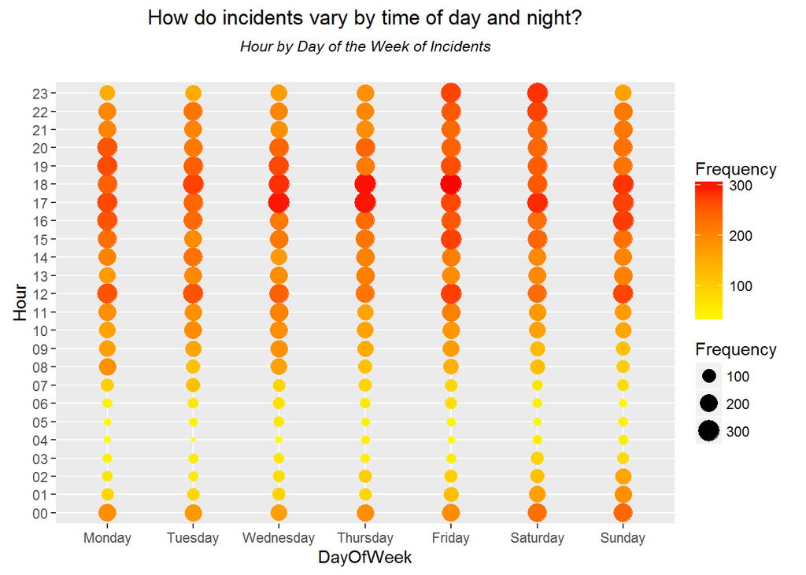

With the geographical coordinates, it is possible to identify precisely the location of the incidents and relate to categories and periods. Larceny/theft and somewhat of Warrants are more predominant in the bay area, while Vehicle Theft are spread across the city.

```r
SF$Latitude   <- SF$Y
SF$Longitude  <- SF$X
# filter top 5 relevant categories
SF_sub <- subset(SF, Category %in% c("Larceny/theft", "Assault",
                                              "Vehicle Theft", "Warrants",
                                              "Drug/narcotic"))
SF_sub$Category <- factor(SF_sub$Category)
```

```
## Using zoom = 13...
```

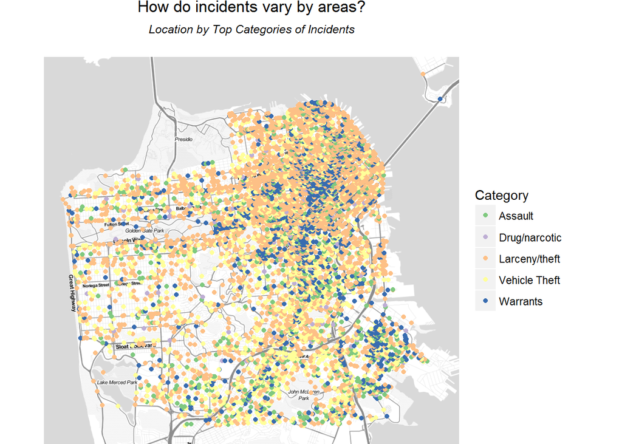

| Assault | Drug/narcotic | Larceny/theft | Vehicle Theft | Warrants |
| --- | --- | --- | --- | --- |
| 2882 | 1345 | 9466 | 1966 | 1782 |

When filtering Larceny/Theft only and checking for the Day of the Week, there is a concentration in the bay ares and on Fridays and weekends.

```r
SF_sub <- subset(SF, Category == "Larceny/theft")
Data <- dcast(SF_sub, Latitude + Longitude + DayOfWeek ~ .)
colnames(Data) <- c("Latitude", "Longitude", "DayOfWeek", "Frequency")
```

```
## Using zoom = 13...
```

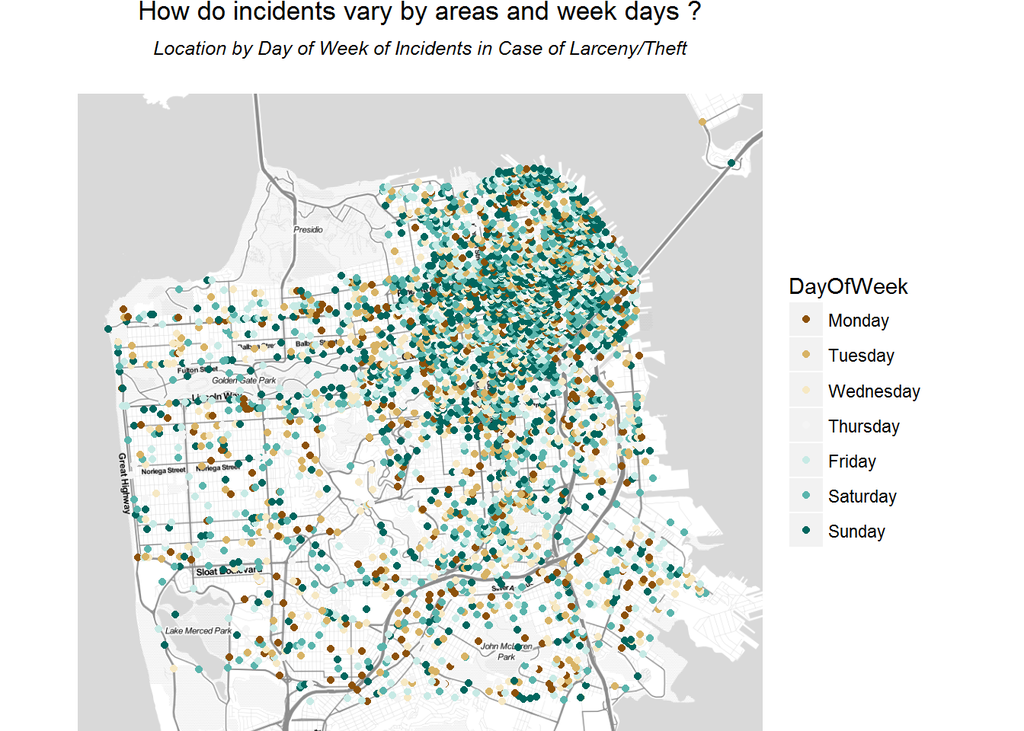

| Monday | Tuesday | Wednesday | Thursday | Friday | Saturday | Sunday |
| --- | --- | --- | --- | --- | --- | --- |
| 1233 | 1237 | 1228 | 1235 | 1445 | 1583 | 1505 |